# Comparison of Sentiment Tools across Domains

### Requirements

Please install and load all required libraries before executing this notebook.

```r
# install required libraries
#install.packages("quanteda")
#install.packages("devtools")
#devtools::install_github("quanteda/quanteda.sentiment")
#install.packages("vader")
#install.packages("readtext")
#install.packages("tidyverse")
#install.packages("tidytext")
#install.packages("reshape2")

# load required libraries
library(quanteda)
library(quanteda.sentiment)
library(vader)
library(readtext)
library(tidyverse)
library(tidytext)
library(reshape2)
```

### 1. Step: Load Corpus Data & Sentiment Lexicons

We start with loading the corpus data and the sentiment lexicons. Here we will load the baseline data sets as an example for the following code. The preprocessed data sets (configurations) can be found within the `datasets/configurations` subdirectory.

```r
# ===== DATASETS =====
# to load data sets, make sure to first set working directory to sentiment tools folder
#setwd(/sentiment_tools)

# load BASELINE data sets: book reviews, twitter, parlvote, amazon reviews, finance
reviews <- readRDS(file="../datasets/baseline/books_config_base.rds")
twitter <- readRDS(file="../datasets/baseline/twitter_config_base.rds")
parlvote <- readRDS(file="../datasets/baseline/parl_config_base.rds")
amazon <- readRDS(file="../datasets/baseline/ama_config_base.rds")
finance <- readRDS(file="../datasets/baseline/fin_config_base.rds")

# ===== SENTIMENT LEXICONS ======
# load lexicons
afinn <- data_dictionary_AFINN
lsd <- data_dictionary_LSD2015
```

##### Look at Example Corpus: ParlVote

Each corpus is loaded as a data frame which consists of the following columns:  
- ID: original document id  
- Text: will be the input to the sentiment analysis  
- Rating: will be the gold standard to evaluate lexicon performance

|  | id | text | rating |
| --- | --- | --- | --- |
| 8235 | 1 | The Home Secretary is rightly dealing with the theme of values. What about the value to which Lord Carlile referred when he criticised the excessive use of section 44 of the Terrorism Act 2000? He des… | -1 |
| 14502 | 2 | Can the Minister tell me why this coalition Government are so determined to pick on children?Does my right hon Friend agree that if the measures were due to financial constraints, the Conservatives wo… | -1 |
| 12629 | 3 | Does the hon Gentleman agree that the programme motion demonstrates a strange order of priorities by giving the law of homophobic hatred an hour, when its likely use in any given year, if implemented,… | -1 |
| 3859 | 4 | I understand the Secretary of State's argument, but his concentrating on countries rather than individual cases gives me cause for concern. A particular country could be safe by and large, but it migh… | -1 |
| 9700 | 5 | The Solicitor-General outlines the way in which the police will contact the CPS and how the CPS will make decisions. It seems ambitious to think that that will all be done in 48 hours. Have the pilots… | -1 |
| 9627 | 6 | Will the Minister explain how we get around the conundrum that was raised in another place about the contrast between Birmingham and Coventry? She says that an airport can raise charges when there is … | -1 |
| 22410 | 7 | I am sure that the Minister will agree that half the population are women and the vast majority of them are successful and contributing, not victims, as the Labour party would have us believe. Does sh… | -1 |
| 20040 | 8 | I congratulate my hon Friend on the work he put into the Bill, which is a worthwhile contribution to localism. Does he agree that one great virtue of localism is that it gives elected local authoritie… | -1 |
| 2667 | 9 | As we are in a vein of transparency, openness and frankness, will the hon Gentleman care to put on record the date on which the Leader of the Opposition agreed to the proposed names? | -1 |
| 11190 | 10 | Does the right hon Lady recognise that it is the very opacity of conventional accounting that worries people when they are confronted by the existence of operations such as Granite, which did not come… | -1 |

[output cut: 990 more lines]

### 2. Step: Sentiment Analysis

#### 2.1 Normalize Scores

To normalize our sentiment scores, we use a customized min/max normalization method here, to make sure all values of the Afinn lexicon are scaled with respect to Afinn’s minimum label (-5) and maximum label (+5). The computed sentiment scores will be normalized between -1 and +1.  
The Lexicoder (LSD) and Vader lexicon are automatically normalized by the `vader` (VADER) function of the *vader* library and the `textstat_polarity` (LSD) function of the *quanteda.sentiment* library.

```r
# ===== DATA NORMALIZATION =====

# Normalize data via minimun/maximum normalization, either by scaling values from 0 to 1 or -1 to 1
#
# Arg:
#   x: input values (e.g. column of data frame)
#
# Returns:
#   normalized data

# min/max normalization from -1 to 1, relative to data frame results
normalize <- function(x, na.rm = TRUE){
  return(2* ((x - min(x)) / (max(x)-min(x)))-1)}

# min/max normalization for afinn data, wrt to afinn scoring (-5, +5)
normalize_afinn <- function(x, na.rm = TRUE){
  return(2* ((x - (-5)) / (5-(-5)))-1)}
```

#### 2.2 Compute Sentiment Scores

NOTE: It could take a few minutes to run this function on the data sets.  
In this step sentiment scores for the different lexicons (Afinn, LSD and Vader) are calculated by using the `texstat_valence` (Afinn) and `textstat_polarity` (LSD) functions of the *quanteda.sentiment* library and the `vader_compound` score of the *vader* library. Originally two versions of normalization were tested. For the final sentiment scoring we decided on the `normalize_afinn` function which can be found in the previous code cell.

```r
# ===== SENTIMENT SCORES =====

# Calculate sentiment scores for different lexicons and input data frames
#
# Arg:
#  data: input data frame
#  lexicons: names of lexicons that should be used for sentiment scoring
#  normalize: "relative" if normalization is handled relative to output, i.e. output column of afinn is being scaled via min/max normalization
#  normalize: "afinn" if normalization is handled by taking -5 as new minimum and +5 as new maximum and everything else is scaled between
#  get_tokens: if TRUE final data frame consists of single tokens with an associated sentiment score
#              else final data frame consists of an associated sentiment score per input text instead (only used to calculate TOP-N words)
#
# Returns:
#  data frame with (normalized) sentiment sores for chosen lexicons

get_sentiment <- function(df, lexicons, normalize, get_tokens){

   # if we want data frame with single tokens
  if(get_tokens==TRUE){
    df <- df %>%
      # get list of tokens as new col in data frame
      unnest_tokens(token,text)

    # assign the new col as input for sentiment lexicons
    tok = df$token

    # for each lexicon, get sentiment scores and save scores in new column of data frame
    for(lex in lexicons){

      # for afinn, use textstat_valence function by quanteda.sentiment
      # normalize = dictionary is used here to average over only the valenced words
      if(lex == "afinn"){
        df$afinn <- round(textstat_valence(tok, afinn, normalize="dictionary")$sentiment,3)}

      # for lexicoder, use textstat_polarity function by quanteda.sentiment
      # normalize = sent_relpropdiff equals \frac{pos - neg}{pos + neg} and automatically scales values between -1 and 1
      if(lex == "lsd"){
        df$lsd<- round(textstat_polarity(tok, lsd, fun=sent_relpropdiff)$sentiment,3)}

      # for vader, use vader function by vader library
      # the compound score automatically normalizes the sentiment score and scales values between -1 and 1
      if(lex == "vader"){
        df$vader <- round(vader_df(tok)$compound,3)}
   }

   # if we don't want to analyze single tokens but input text as "whole"
   }else{

      # tokenize text column
      tok = tokens(df$text)

      # for each lexicon, proceed as before
      for(lex in lexicons){
         if(lex == "afinn"){
            df$afinn <- round(textstat_valence(tok, afinn, normalize="dictionary")$sentiment,3)}

         if(lex == "lsd"){
            df$lsd<- round(textstat_polarity(tok, lsd, fun=sent_relpropdiff)$sentiment,3)}

         if(lex == "vader"){
            df$vader <- round(vader_df(df$text)$compound,3)}
     }
   }

   # normalize sentiment scores if TRUE, VADER and LSD scores are already normalized within functions above
   if(normalize=="afinn"){
      df$afinn <- round(normalize_afinn(df$afinn), 3)
   }else{
      df$afinn <- round(normalize(df$afinn), 3)}

   # set sentiment scores to 0 if NA
   df[is.na(df)] <- 0

   return(df)
}

# apply get_sentiment function to corpus data
### BASELINE corpora
reviews_sentiment_norm1 <- get_sentiment(reviews, c("afinn","lsd", "vader"), normalize="afinn", get_tokens=FALSE)
twitter_sentiment_norm1 <- get_sentiment(twitter, c("afinn","lsd", "vader"), normalize="afinn", get_tokens=FALSE)
parlvote_sentiment_norm1 <- get_sentiment(parlvote, c("afinn","lsd", "vader"), normalize="afinn", get_tokens=FALSE)
amazon_sentiment_norm1 <- get_sentiment(amazon, c("afinn", "lsd", "vader"), normalize="afinn", get_tokens=FALSE)
finance_sentiment_norm1 <- get_sentiment(finance, c("afinn", "lsd", "vader"), normalize="afinn", get_tokens=FALSE)
```

### 3. Step (Optional): Convert Data into discrete format

With this optional step, the data can be converted into a discrete format with the variables being 1 = positive, 0 = neutral, -1 = negative.

```r
# Convert final values into discrete (1 = positive, 0 = neutral, -1 = negative) format for evaluation and comparison
#
# Arg:
#   df: input data frame that contains the columns to be converted into ternary format
#   to_change: column names that should be converted into ternary format
#
# Returns:
#   data frame with converted values

get_discrete <- function(df, to_change){
  df %>%
    mutate_at(to_change, function(x){
      # mutate values greater than 0 to 1 (positive), equal to 0 to 0 (neutral) and smaller than 0 to -1 (negative)
      case_when(x > 0 ~ 1, x < 0 ~ -1, x == 0 ~ 0)})# %>%
}

# apply to data sets
reviews_discrete <- get_discrete(reviews_sentiment_norm1, c("afinn","vader","lsd"))
twitter_discrete <- get_discrete(twitter_sentiment_norm1, c("afinn","vader","lsd"))
parlvote_discrete <- get_discrete(parlvote_sentiment_norm1, c("afinn","vader","lsd"))
amazon_discrete <- get_discrete(amazon_sentiment_norm1, c("afinn","vader","lsd"))
finance_discrete <- get_discrete(finance_sentiment_norm1, c("afinn","vader","lsd"))
```

### 4. Step: Compute Coverage

To compute the coverage of each sentiment lexicon and for each corpus, we consider all texts or tokens receiving a score of 0 to be non-recognized by the according lexicon (in `get_sentiment`, we set all *NA* values to 0, since we consider non-recognized sentences to be of neutral polarity), i.e. the word does not exist in the lexicon or the whole text did not contain a word which is contained in the lexicon. We compute the coverage per token and the coverage per text. In case of the coverage per token, we consider 2 configurations: 1) a baseline configuration with a simple token-count to compute the coverage score, 2) a configuration of the tokens with a prior stopword removal.

```r
# get sentiment token-wise in corpus
reviews_tok_sent <- get_sentiment(reviews, c("afinn","lsd", "vader"), normalize="afinn", get_tokens=TRUE)
twitter_tok_sent <- get_sentiment(twitter, c("afinn","lsd", "vader"), normalize="afinn", get_tokens=TRUE)
parlvote_tok_sent <- get_sentiment(parlvote, c("afinn","lsd", "vader"), normalize="afinn", get_tokens=TRUE)
amazon_tok_sent <- get_sentiment(amazon, c("afinn","lsd", "vader"), normalize="afinn", get_tokens=TRUE)
finance_tok_sent <- get_sentiment(finance, c("afinn", "lsd", "vader"), normalize="afinn", get_tokens=TRUE)

# load stopwords
data(stop_words)
```

```r
# ===== COVERAGE PER TOKEN =====

# Coverage per token: if sentiment score is not zero, count as "covered", get percentage of covered tokens
reviews_tok_coverage <- `rownames<-`(data.frame(t(round(colSums(reviews_tok_sent[c("afinn","lsd","vader")] != 0)/colSums(reviews_tok_sent != 0)[[1]]*100,2))), "reviews tokens")
twitter_tok_coverage <- `rownames<-`(data.frame(t(round(colSums(twitter_tok_sent[c("afinn","lsd","vader")] != 0)/colSums(twitter_tok_sent != 0)[[1]]*100,2))), "twitter tokens")
parlvote_tok_coverage <- `rownames<-`(data.frame(t(round(colSums(parlvote_tok_sent[c("afinn","lsd","vader")] != 0)/colSums(parlvote_tok_sent != 0)[[1]]*100,2))), "parlvote tokens")
amazon_tok_coverage <- `rownames<-`(data.frame(t(round(colSums(amazon_tok_sent[c("afinn","lsd","vader")] != 0)/colSums(amazon_tok_sent != 0)[[1]]*100,2))), "amazon tokens")
finance_tok_coverage <- `rownames<-`(data.frame(t(round(colSums(finance_tok_sent[c("afinn","lsd","vader")] != 0)/colSums(finance_tok_sent != 0)[[1]]*100,2))), "finance tokens")

# Coverage per token: with prior stopword removal

# remove stopwords from each data frame
reviews_tok.stopwords <- reviews_tok_sent %>%
   anti_join(stop_words, by= c("token" = "word") ) %>%
   ungroup()

twitter_tok.stopwords <- twitter_tok_sent %>%
   anti_join(stop_words, by= c("token" = "word") ) %>%
   ungroup()

parlvote_tok.stopwords <- parlvote_tok_sent %>%
   anti_join(stop_words, by= c("token" = "word") ) %>%
   ungroup()

amazon_tok.stopwords <- amazon_tok_sent %>%
   anti_join(stop_words, by= c("token" = "word") ) %>%
   ungroup()

finance_tok.stopwords <- finance_tok_sent %>%
   anti_join(stop_words, by= c("token" = "word") ) %>%
   ungroup()

# same as above: if sentiment score is not zero, count as "covered", get percentage of covered tokens
reviews_tok_coverage.stopwords <- `rownames<-`(data.frame(t(round(colSums(reviews_tok.stopwords[c("afinn","lsd","vader")] != 0)/colSums(reviews_tok.stopwords != 0)[[1]]*100,2))), "reviews tokens (sw)")
twitter_tok_coverage.stopwords <- `rownames<-`(data.frame(t(round(colSums(twitter_tok.stopwords[c("afinn","lsd","vader")] != 0)/colSums(twitter_tok.stopwords != 0)[[1]]*100,2))), "twitter tokens (sw)")
parlvote_tok_coverage.stopwords <- `rownames<-`(data.frame(t(round(colSums(parlvote_tok.stopwords[c("afinn","lsd","vader")] != 0)/colSums(parlvote_tok.stopwords != 0)[[1]]*100,2))), "parlvote tokens (sw)")
amazon_tok_coverage.stopwords <- `rownames<-`(data.frame(t(round(colSums(amazon_tok.stopwords[c("afinn","lsd","vader")] != 0)/colSums(amazon_tok.stopwords != 0)[[1]]*100,2))), "amazon tokens (sw)")
finance_tok_coverage.stopwords <- `rownames<-`(data.frame(t(round(colSums(finance_tok.stopwords[c("afinn","lsd","vader")] != 0)/colSums(finance_tok.stopwords != 0)[[1]]*100,2))), "finance tokens (sw)")

# ===== COVERAGE PER TEXT =====

# Coverage per text: if sentiment score is not zero, count as "covered", get percentage of covered text instances
reviews_coverage <- `rownames<-`(data.frame(t(colSums(reviews_sentiment_norm1[c("afinn","lsd","vader")] != 0)/10)), "reviews text")
twitter_coverage <- `rownames<-`(data.frame(t(colSums(twitter_sentiment_norm1[c("afinn","lsd","vader")] != 0)/10)), "twitter text")
parlvote_coverage <- `rownames<-`(data.frame(t(colSums(parlvote_sentiment_norm1[c("afinn","lsd","vader")] != 0)/10)), "parlvote text")
amazon_coverage <- `rownames<-`(data.frame(t(colSums(amazon_sentiment_norm1[c("afinn","lsd","vader")] != 0)/10)), "amazon text")
finance_coverage <- `rownames<-`(data.frame(t(colSums(finance_sentiment_norm1[c("afinn","lsd","vader")] != 0)/10)), "finance text")

# save data to data frame
coverage <- rbind(reviews_tok_coverage,reviews_tok_coverage.stopwords,reviews_coverage, twitter_tok_coverage,twitter_tok_coverage.stopwords,parlvote_tok_coverage,twitter_coverage,parlvote_tok_coverage.stopwords, parlvote_coverage, amazon_tok_coverage,amazon_tok_coverage.stopwords, amazon_coverage, finance_tok_coverage,finance_tok_coverage.stopwords, finance_coverage)
```

#### Display Coverage Results

|  | afinn | lsd | vader |
| --- | --- | --- | --- |
| reviews tokens | 6.99 | 9.14 | 8.84 |
| reviews tokens (sw) | 14.15 | 20.26 | 18.14 |
| reviews text | 90.70 | 87.70 | 96.50 |
| twitter tokens | 6.68 | 8.15 | 7.99 |
| twitter tokens (sw) | 9.06 | 12.65 | 11.34 |
| parlvote tokens | 5.11 | 7.41 | 7.02 |
| twitter text | 49.10 | 49.90 | 57.10 |
| parlvote tokens (sw) | 11.09 | 18.28 | 15.82 |
| parlvote text | 82.70 | 83.60 | 93.10 |
| amazon tokens | 6.27 | 8.44 | 7.90 |

[output cut: 5 more lines]

### 5. Step: Plot Data

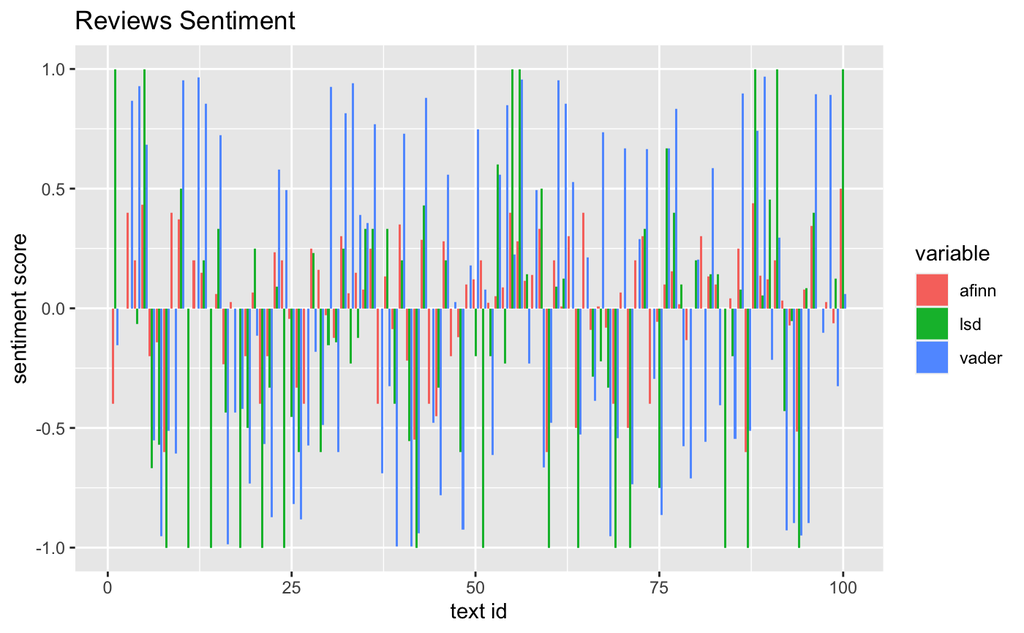

```r
# ===== PLOT SENTIMENT SCORES =====

# create data frame with sentiment scores as variable of first 100 instances of corpus
reviews_df <- melt(head(reviews_sentiment_norm1,100)[,c('id','afinn','lsd','vader')],id.vars = 1)
parlvote_df <- melt(head(parlvote_sentiment_norm1,100)[,c('id','afinn','lsd','vader')],id.vars = 1)

# create plots for each corpus
reviews_plot <- ggplot(reviews_df,aes(x = id,y = value)) +
                geom_bar(aes(fill = variable),stat = "identity",position = "dodge") +
                xlab("text id")+ ylab("sentiment score")+
                ggtitle("Reviews Sentiment")

parlvote_plot.line <- ggplot(parlvote_df,aes(x = id, y = value, group=variable)) +
                      geom_line(aes(colour=variable), size=0.4)+
                      ylim(-2,2) +
                      xlab("text id")+ ylab("sentiment score")+
                      ggtitle("ParlVote Sentiment Scores")

# show plots
reviews_plot
```

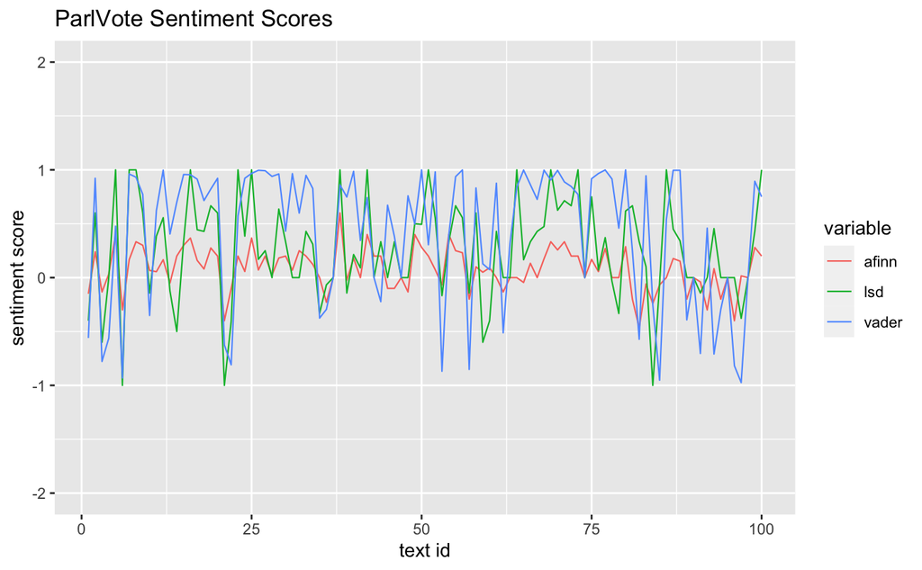

```r
parlvote_plot.line
```

#### 5.2 Plot Important Words

In the next step, word counts for each discrete (sentiment) variable (“positive”, “negative”, “neutral”) are retrieved for each lexicon.

```r
# get word counts per discrete variable ("positive", "negative", "neutral", i.e. 1,-1,0)
reviews_afinn.word_counts <- reviews_tok_discrete %>%
   count(token, afinn, sort = TRUE) %>%
   anti_join(stop_words, by= c("token" = "word") ) %>%
   ungroup()

reviews_lsd.word_counts <- reviews_tok_discrete %>%
   count(token, lsd, sort = TRUE) %>%
   anti_join(stop_words, by= c("token" = "word") ) %>%
   ungroup()

reviews_vader.word_counts <- reviews_tok_discrete %>%
   count(token, vader, sort = TRUE) %>%
   anti_join(stop_words, by= c("token" = "word") ) %>%
   ungroup()
```

Now we can plot the top 20 words for each sentiment. Contribution to sentiment here is equal to the according word’s frequency.

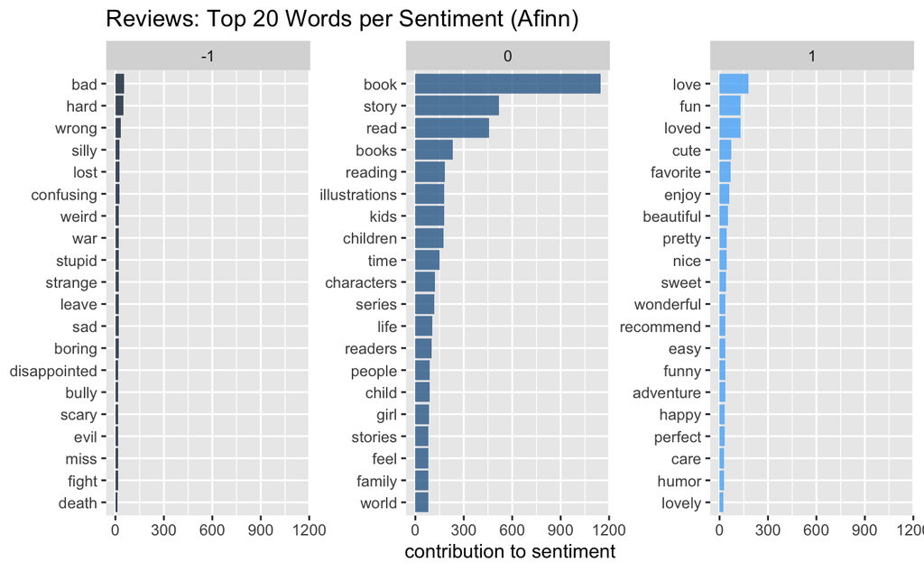

```r
# plot top n words for each sentiment and for each lexicon, n = 20
topn_reviews_afinn.plot <- reviews_afinn.word_counts %>%
         group_by(afinn) %>%
         slice(1:20) %>%
         ggplot(aes(reorder(token, n), n, fill = afinn)) +
           geom_bar(alpha = 0.8, stat = "identity", show.legend = FALSE) +
           facet_wrap(~afinn, scales = "free_y") +
           labs(y = "contribution to sentiment", x = NULL) +
           coord_flip()+
           ggtitle("Reviews: Top 20 Words per Sentiment (Afinn)")

topn_reviews_lsd.plot <- reviews_lsd.word_counts %>%
         group_by(lsd) %>%
         slice(1:20) %>%
         ggplot(aes(reorder(token, n), n, fill = lsd)) +
           geom_bar(alpha = 0.8, stat = "identity", show.legend = FALSE) +
           facet_wrap(~lsd, scales = "free_y") +
           labs(y = "contribution to sentiment", x = NULL) +
           coord_flip()+
           ggtitle("Reviews: Top 20 Words per Sentiment (LSD)")

topn_reviews_vader.plot <- reviews_vader.word_counts %>%
         group_by(vader) %>%
         slice(1:20) %>%
         ggplot(aes(reorder(token, n), n, fill = vader)) +
           geom_bar(alpha = 0.8, stat = "identity", show.legend = FALSE) +
           facet_wrap(~vader, scales = "free_y") +
           labs(y = "contribution to sentiment", x = NULL) +
           coord_flip()+
           ggtitle("Reviews: Top 20 Words per Sentiment (VADER)")

topn_reviews_afinn.plot
```

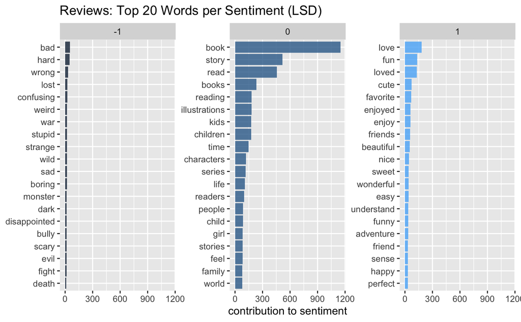

```r
topn_reviews_lsd.plot
```

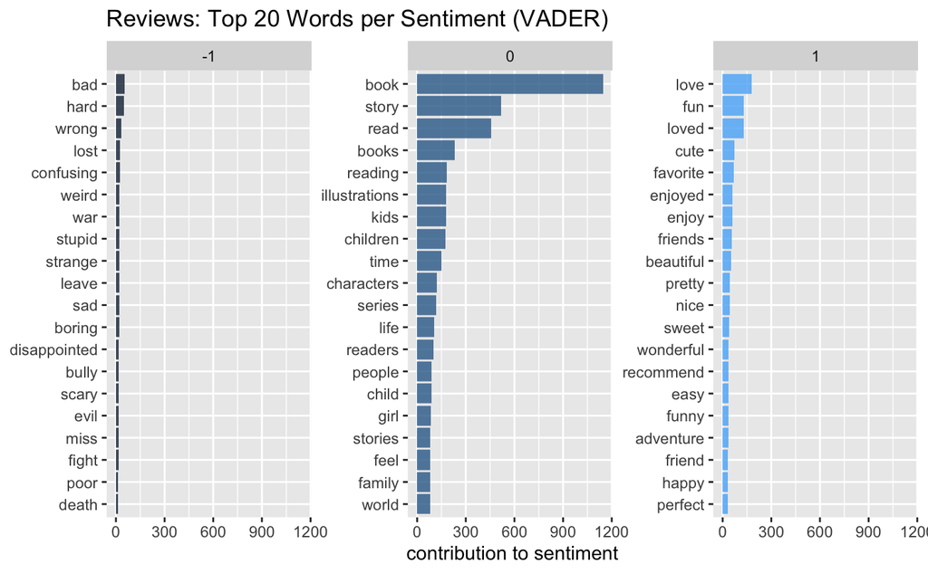

```r
topn_reviews_vader.plot
```

#### 5.3 Plot Coverage

In the next step, we plot the coverage of the sentiment lexicons. We will plot  
- the coverage per token  
- the coverage per token (with prior stopword removal)  
- the coverage per text

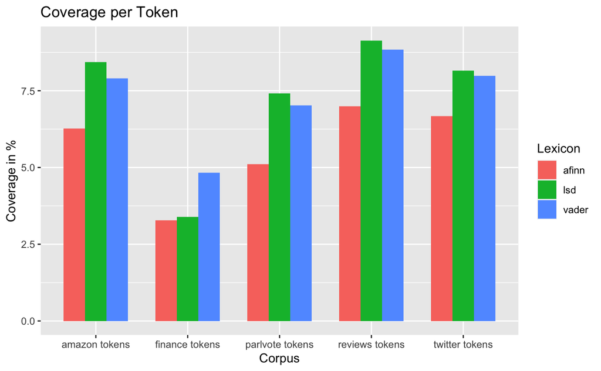

```r
# ===== PREPARE DATA FOR PLOTTING =====
# create separate data frames we want to plot
coverage_per_text <- rbind(reviews_coverage,twitter_coverage,parlvote_coverage,amazon_coverage,finance_coverage)
coverage_per_tok <- rbind(reviews_tok_coverage,twitter_tok_coverage,parlvote_tok_coverage,amazon_tok_coverage, finance_tok_coverage)
coverage_per_tok.stopwords <- rbind(reviews_tok_coverage.stopwords, twitter_tok_coverage.stopwords,parlvote_tok_coverage.stopwords,amazon_tok_coverage.stopwords,finance_tok_coverage.stopwords)

# add corpus names as row names
coverage_per_tok["corpus"] <- rownames(coverage_per_tok)
coverage_per_tok.stopwords["corpus"] <- rownames(coverage_per_tok.stopwords)
coverage_per_text["corpus"] <- rownames(coverage_per_text)

# prepare data for plotting
cov_tok_df <- melt(coverage_per_tok,id.vars = "corpus", value.name="coverage", variable.name="Lexicon")
cov_tok_df.stopwords <- melt(coverage_per_tok.stopwords,id.vars = "corpus", value.name="coverage", variable.name="Lexicon")
cov_text_df <- melt(coverage_per_text,id.vars = "corpus", value.name="coverage", variable.name="Lexicon")

# ===== COVERAGE PLOTS =====
# create plots
cov_tok_plot <- ggplot(cov_tok_df,aes(x=corpus, y = coverage)) +
                geom_bar(aes(fill = Lexicon),stat = "identity",position = "dodge", width= 0.7) +
                xlab("Corpus")+ ylab("Coverage in %")+
                ggtitle("Coverage per Token")

cov_tok_plot.stopwords <- ggplot(cov_tok_df.stopwords,aes(x=corpus, y = coverage)) +
                geom_bar(aes(fill = Lexicon),stat = "identity",position = "dodge", width= 0.7) +
                xlab("Corpus")+ ylab("Coverage in %")+
                ggtitle("Coverage per Token - Stopwords")

cov_text_plot <- ggplot(cov_text_df,aes(x=corpus, y = coverage)) +
                geom_bar(aes(fill = Lexicon),stat = "identity",position = "dodge", width= 0.7) +
                xlab("Corpus")+ ylab("Coverage in %")+
                ggtitle("Coverage per Text")

# show plots
cov_tok_plot
```

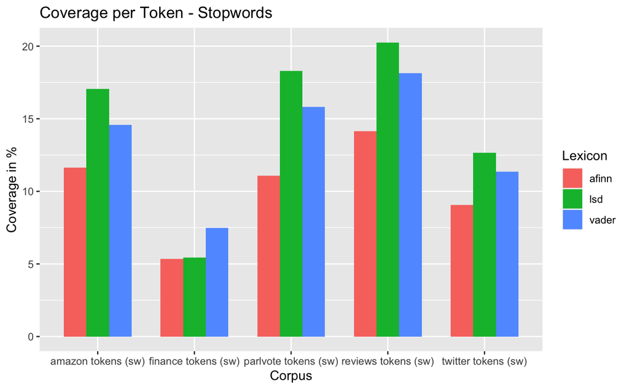

```r
cov_tok_plot.stopwords
```

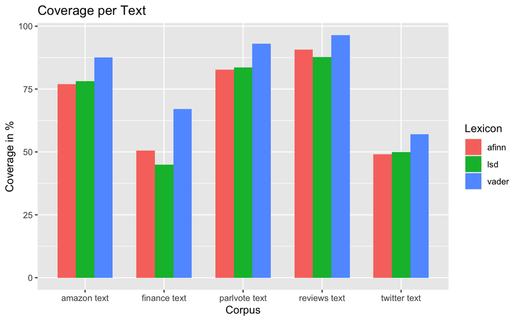

```r
cov_text_plot
```